# exploratory_analysis

**Loan Data investigation**

**Table of Contents**

- Introduction
- Dataset Overview
- Cleaning
- Exploratory Visualizations
- Conclusions

```python
# import all packages and set plots to be embedded inline
import matplotlib.pyplot as plt
import seaborn as sns
import pandas as pd
import numpy as np
import warnings
import re

# plt.style.use('seaborn-whitegrid')
sns.set_style('whitegrid')
# plt.style.use('seaborn-white')
plt.style.use('seaborn-deep')

pd.options.mode.chained_assignment = None  # default='warn'
%matplotlib inline
```

```python
class Color:
    PURPLE = '\033[95m'
    CYAN = '\033[96m'
    DARKCYAN = '\033[36m'
    BLUE = '\033[94m'
    GREEN = '\033[92m'
    YELLOW = '\033[93m'
    RED = '\033[91m'
    BOLD = '\033[1m'
    UNDERLINE = '\033[4m'
    END = '\033[0m'
```

**Introduction**

We will start by having a general overview on the dataset, pointing out the main variables, with their meanings, we will be focusing on.  
Then we will start cleaning our dataset to be suitable for the scope of this analysis  
And then we will show some general visualized-analysis that points out some correlations between variables and have some insights that help in answering the following main questions at the end of the analysis:

- What factors affect a loan’s outcome status?
- What affects the borrower’s APR or interest rate?

**Dataset Overview**

```python
# load datasets
loans_df = pd.read_csv('prosperLoanData.csv')
schema_df = pd.read_csv('schema_ProsperLoanData.csv', index_col = 'Variable')
```

```python
print(loans_df.shape)
print(schema_df.shape, '\n')

loans_df.head(3)
```

```
(113937, 81)
(81, 1)
```

|  | ListingKey | ListingNumber | ListingCreationDate | CreditGrade | Term | LoanStatus | ClosedDate | BorrowerAPR | BorrowerRate | LenderYield | ... | LP_ServiceFees | LP_CollectionFees | LP_GrossPrincipalLoss | LP_NetPrincipalLoss | LP_NonPrincipalRecoverypayments | PercentFunded | Recommendations | InvestmentFromFriendsCount | InvestmentFromFriendsAmount | Investors |
| --- | --- | --- | --- | --- | --- | --- | --- | --- | --- | --- | --- | --- | --- | --- | --- | --- | --- | --- | --- | --- | --- |
| 0 | 1021339766868145413AB3B | 193129 | 2007-08-26 19:09:29.263000000 | C | 36 | Completed | 2009-08-14 00:00:00 | 0.16516 | 0.158 | 0.138 | ... | -133.18 | 0.0 | 0.0 | 0.0 | 0.0 | 1.0 | 0 | 0 | 0.0 | 258 |
| 1 | 10273602499503308B223C1 | 1209647 | 2014-02-27 08:28:07.900000000 | NaN | 36 | Current | NaN | 0.12016 | 0.092 | 0.082 | ... | 0.00 | 0.0 | 0.0 | 0.0 | 0.0 | 1.0 | 0 | 0 | 0.0 | 1 |
| 2 | 0EE9337825851032864889A | 81716 | 2007-01-05 15:00:47.090000000 | HR | 36 | Completed | 2009-12-17 00:00:00 | 0.28269 | 0.275 | 0.240 | ... | -24.20 | 0.0 | 0.0 | 0.0 | 0.0 | 1.0 | 0 | 0 | 0.0 | 41 |

3 rows × 81 columns

```python
pd.set_option('display.max_colwidth', None,
              'display.max_columns', None,
              'display.max_rows', None,
#               'display.width', None,
#               'display.max_colwidth', 0
              )
schema_df
```

| Variable | Description |
| --- | --- |
| ListingKey | Unique key for each listing, same value as the 'key' used in the listing object in the API. |
| ListingNumber | The number that uniquely identifies the listing to the public as displayed on the website. |
| ListingCreationDate | The date the listing was created. |
| CreditGrade | The Credit rating that was assigned at the time the listing went live. Applicable for listings pre-2009 period and will only be populated for those listings. |
| Term | The length of the loan expressed in months. |
| LoanStatus | The current status of the loan: Cancelled, Chargedoff, Completed, Current, Defaulted, FinalPaymentInProgress, PastDue. The PastDue status will be accompanied by a delinquency bucket. |
| ClosedDate | Closed date is applicable for Cancelled, Completed, Chargedoff and Defaulted loan statuses. |
| BorrowerAPR | The Borrower's Annual Percentage Rate (APR) for the loan. |
| BorrowerRate | The Borrower's interest rate for this loan. |
| LenderYield | The Lender yield on the loan. Lender yield is equal to the interest rate on the loan less the servicing fee. |
| EstimatedEffectiveYield | Effective yield is equal to the borrower interest rate (i) minus the servicing fee rate, (ii) minus estimated uncollected interest on charge-offs, (iii) plus estimated collected late fees. Applicable … |
| EstimatedLoss | Estimated loss is the estimated principal loss on charge-offs. Applicable for loans originated after July 2009. |
| EstimatedReturn | The estimated return assigned to the listing at the time it was created. Estimated return is the difference between the Estimated Effective Yield and the Estimated Loss Rate. Applicable for loans orig… |
| ProsperRating (numeric) | The Prosper Rating assigned at the time the listing was created: 0 - N/A, 1 - HR, 2 - E, 3 - D, 4 - C, 5 - B, 6 - A, 7 - AA. Applicable for loans originated after July 2009. |
| ProsperRating (Alpha) | The Prosper Rating assigned at the time the listing was created between AA - HR. Applicable for loans originated after July 2009. |
| ProsperScore | A custom risk score built using historical Prosper data. The score ranges from 1-10, with 10 being the best, or lowest risk score. Applicable for loans originated after July 2009. |
| ListingCategory | The category of the listing that the borrower selected when posting their listing: 0 - Not Available, 1 - Debt Consolidation, 2 - Home Improvement, 3 - Business, 4 - Personal Loan, 5 - Student Use, 6 … |
| BorrowerState | The two letter abbreviation of the state of the address of the borrower at the time the Listing was created. |
| Occupation | The Occupation selected by the Borrower at the time they created the listing. |
| EmploymentStatus | The employment status of the borrower at the time they posted the listing. |
| EmploymentStatusDuration | The length in months of the employment status at the time the listing was created. |
| IsBorrowerHomeowner | A Borrower will be classified as a homowner if they have a mortgage on their credit profile or provide documentation confirming they are a homeowner. |
| CurrentlyInGroup | Specifies whether or not the Borrower was in a group at the time the listing was created. |
| GroupKey | The Key of the group in which the Borrower is a member of. Value will be null if the borrower does not have a group affiliation. |
| DateCreditPulled | The date the credit profile was pulled. |
| CreditScoreRangeLower | The lower value representing the range of the borrower's credit score as provided by a consumer credit rating agency. |
| CreditScoreRangeUpper | The upper value representing the range of the borrower's credit score as provided by a consumer credit rating agency. |
| FirstRecordedCreditLine | The date the first credit line was opened. |
| CurrentCreditLines | Number of current credit lines at the time the credit profile was pulled. |
| OpenCreditLines | Number of open credit lines at the time the credit profile was pulled. |

[output cut: 51 more lines]

```python
pd.reset_option('^display.', silent=True) # restore the default pandas options for printing
```

### Selected features

```python
selected_cols = ['ListingCreationDate', 'Term', 'LoanStatus', 'ClosedDate', 'BorrowerAPR', 'ProsperRating (Alpha)', 'ListingCategory (numeric)', 'Occupation', 'EmploymentStatus', 'IsBorrowerHomeowner', 'DebtToIncomeRatio', 'IncomeRange', 'StatedMonthlyIncome', 'Recommendations', 'LoanOriginalAmount', 'MonthlyLoanPayment', 'Investors']
schema_df.rename({'ListingCategory':'ListingCategory (numeric)'}, inplace=True)
df = loans_df[selected_cols]
```

```python
df.head(3)
```

|  | ListingCreationDate | Term | LoanStatus | ClosedDate | BorrowerAPR | ProsperRating (Alpha) | ListingCategory (numeric) | Occupation | EmploymentStatus | IsBorrowerHomeowner | DebtToIncomeRatio | IncomeRange | StatedMonthlyIncome | Recommendations | LoanOriginalAmount | MonthlyLoanPayment | Investors |
| --- | --- | --- | --- | --- | --- | --- | --- | --- | --- | --- | --- | --- | --- | --- | --- | --- | --- |
| 0 | 2007-08-26 19:09:29.263000000 | 36 | Completed | 2009-08-14 00:00:00 | 0.16516 | NaN | 0 | Other | Self-employed | True | 0.17 | $25,000-49,999 | 3083.333333 | 0 | 9425 | 330.43 | 258 |
| 1 | 2014-02-27 08:28:07.900000000 | 36 | Current | NaN | 0.12016 | A | 2 | Professional | Employed | False | 0.18 | $50,000-74,999 | 6125.000000 | 0 | 10000 | 318.93 | 1 |
| 2 | 2007-01-05 15:00:47.090000000 | 36 | Completed | 2009-12-17 00:00:00 | 0.28269 | NaN | 0 | Other | Not available | False | 0.06 | Not displayed | 2083.333333 | 0 | 3001 | 123.32 | 41 |

```python
# I printed them here to easily go back and check their meaning by searching for {*column_name} or search for schema_meanings
print(f'\t\t\t\t\t\t\t{Color.RED}schema_meanings{Color.END}\n')

for col_name in selected_cols:
    print(f'{Color.GREEN}*{col_name}{Color.END}', ': ', schema_df.loc[col_name, 'Description'])
```

```
							schema_meanings

*ListingCreationDate :  The date the listing was created.
*Term :  The length of the loan expressed in months.
*LoanStatus :  The current status of the loan: Cancelled,  Chargedoff, Completed, Current, Defaulted, FinalPaymentInProgress, PastDue. The PastDue status will be accompanied by a delinquency bucket.
*ClosedDate :  Closed date is applicable for Cancelled, Completed, Chargedoff and Defaulted loan statuses.
*BorrowerAPR :  The Borrower's Annual Percentage Rate (APR) for the loan.
*ProsperRating (Alpha) :  The Prosper Rating assigned at the time the listing was created between AA - HR.  Applicable for loans originated after July 2009.
*ListingCategory (numeric) :  The category of the listing that the borrower selected when posting their listing: 0 - Not Available, 1 - Debt Consolidation, 2 - Home Improvement, 3 - Business, 4 - Personal Loan, 5 - Student Use, 6 - Auto, 7- Other, 8 - Baby&Adoption, 9 - Boat, 10 - Cosmetic Procedure…
*Occupation :  The Occupation selected by the Borrower at the time they created the listing.
*EmploymentStatus :  The employment status of the borrower at the time they posted the listing.
*IsBorrowerHomeowner :  A Borrower will be classified as a homowner if they have a mortgage on their credit profile or provide documentation confirming they are a homeowner.
*DebtToIncomeRatio :  The debt to income ratio of the borrower at the time the credit profile was pulled. This value is Null if the debt to income ratio is not available. This value is capped at 10.01 (any debt to income ratio larger than 1000% will be returned as 1001%).
*IncomeRange :  The income range of the borrower at the time the listing was created.
*StatedMonthlyIncome :  The monthly income the borrower stated at the time the listing was created.
*Recommendations :  Number of recommendations the borrower had at the time the listing was created.
*LoanOriginalAmount :  The origination amount of the loan.
*MonthlyLoanPayment :  The scheduled monthly loan payment.
*Investors :  The number of investors that funded the loan.
```

### Datatypes Overview

```python
df.info()
```

```
<class 'pandas.core.frame.DataFrame'>
RangeIndex: 113937 entries, 0 to 113936
Data columns (total 17 columns):
 #   Column                     Non-Null Count   Dtype
---  ------                     --------------   -----
 0   ListingCreationDate        113937 non-null  object
 1   Term                       113937 non-null  int64
 2   LoanStatus                 113937 non-null  object
 3   ClosedDate                 55089 non-null   object
 4   BorrowerAPR                113912 non-null  float64
 5   ProsperRating (Alpha)      84853 non-null   object
 6   ListingCategory (numeric)  113937 non-null  int64
 7   Occupation                 110349 non-null  object
 8   EmploymentStatus           111682 non-null  object
 9   IsBorrowerHomeowner        113937 non-null  bool
 10  DebtToIncomeRatio          105383 non-null  float64
 11  IncomeRange                113937 non-null  object
 12  StatedMonthlyIncome        113937 non-null  float64
 13  Recommendations            113937 non-null  int64
 14  LoanOriginalAmount         113937 non-null  int64
 15  MonthlyLoanPayment         113937 non-null  float64
 16  Investors                  113937 non-null  int64
dtypes: bool(1), float64(4), int64(5), object(7)
memory usage: 14.0+ MB
```

```python
# datatypes of the dataframe
categorical_cols = ['Term', 'LoanStatus', 'ProsperRating (Alpha)', 'ListingCategory (numeric)', 'Occupation', 'EmploymentStatus', 'IncomeRange']
boolean_cols = ['IsBorrowerHomeowner'] # already converted
datetype_cols = ['ListingCreationDate', 'ClosedDate']
numeric_cols = ['BorrowerAPR', 'StatedMonthlyIncome', 'LoanOriginalAmount', 'MonthlyLoanPayment', 'Investors'] # already converted
```

**Cleaning**

### Drop NaNs

```python
df.dropna(inplace=True)
df.isna().any().any() # similar to _.sum().sum()
```

```
False
```

### Map column from numeric values to descriptive strings

```python
values = re.findall('[0-9]+\s*- ([A-Za-z ]+)', schema_df.loc['ListingCategory (numeric)', 'Description'])
keys = range(0, 21)
mapping_ListCategory = dict(zip(keys, values))
mapping_ListCategory
```

```
{0: 'Not Available',
 1: 'Debt Consolidation',
 2: 'Home Improvement',
 3: 'Business',
 4: 'Personal Loan',
 5: 'Student Use',
 6: 'Auto',
 7: 'Other',
 8: 'Baby',
 9: 'Boat',
 10: 'Cosmetic Procedure',
 11: 'Engagement Ring',
 12: 'Green Loans',
 13: 'Household Expenses',
 14: 'Large Purchases',
 15: 'Medical',
 16: 'Motorcycle',
 17: 'RV',
 18: 'Taxes',
 19: 'Vacation',
 20: 'Wedding Loans'}
```

```python
df['ListingCategory'] = df['ListingCategory (numeric)'].apply(lambda x: mapping_ListCategory[x])
list(df['ListingCategory'].head(5)), list(df['ListingCategory (numeric)'].head(5))
```

```
(['Household Expenses',
  'Medical',
  'Debt Consolidation',
  'Debt Consolidation',
  'Wedding Loans'],
 [13, 15, 1, 1, 20])
```

```python
ProsperRating_classes = ['AA', 'A', 'B', 'C', 'D', 'E', 'HR']
ProsperRatingClasses = pd.CategoricalDtype(ordered=True, categories=ProsperRating_classes)
df['ProsperRating'] = df['ProsperRating (Alpha)'].astype(ProsperRatingClasses);
df['ProsperRating'].dtypes
```

```
CategoricalDtype(categories=['AA', 'A', 'B', 'C', 'D', 'E', 'HR'], ordered=True)
```

**Exploratory Visualizations**

At first we will start exploring variables to have an overview about the outliers, skewness, and their correlations with each other.

```python
def decorate_barPlots(ax, title='TITLE', hideAxes=True, direction='v', rotateTextdeg=0):
    '''
        ax : matplotlib.axes._subplots.AxesSubplot
        hideAxes : Hide right and top axes of the plot
        annotate : add numbers related to bar sizes
        direction : v or h which stands for vertical and horizontal
    '''

    if direction == 'v':
        for p in ax.patches:
            bar_length = round(p.get_height(), 4)
            ax.annotate(str(bar_length), xy=(p.get_x() + p.get_width() / 2.0, bar_length),
            xytext=(3, 3),
            textcoords='offset points',
            ha='center',
            va='bottom',
            rotation = rotateTextdeg
                       )
    elif direction == 'h':
        for p in ax.patches:
            bar_length = round(p.get_width(), 4)
            ax.annotate(str(bar_length), xy=(bar_length, p.get_y() + (p.get_height() / 2.0)),
            xytext=(25, 1),
            textcoords='offset points',
            ha='center', # Horizontal Alignment: 'center', 'right', 'left'
            va='center_baseline', # Vertical Alignment:'top', 'bottom', 'center', 'baseline', 'center_baseline'
            rotation = rotateTextdeg
                                )
    else:
        print('Not Annotated!')


    if hideAxes:
        ax.spines['right'].set_visible(False)
        ax.spines['top'].set_visible(False)
        # Only show ticks on the left and bottom spines
        ax.yaxis.set_ticks_position('left')
        ax.xaxis.set_ticks_position('bottom')

    title_obj = ax.set_title(f'{title}', pad=20, fontsize=15)
    plt.setp(title_obj, color='#1D2951');
```

- **Distribution of ProsperRating**

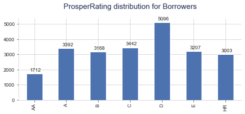

```python
ax = df['ProsperRating'].value_counts().sort_index().plot(kind='bar', figsize=(8,3))
decorate_barPlots(ax, title='ProsperRating distribution for Borrowers')
```

- **General Overview on the categorical variables occurrences**

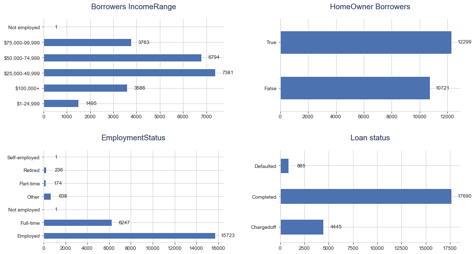

```python
fig = plt.figure(figsize=(13, 7))

ax = plt.subplot(2, 2, 1)
ax = df['IncomeRange'].value_counts().sort_index().plot(kind='barh')
decorate_barPlots(ax, title='Borrowers IncomeRange', direction='h')

ax = plt.subplot(2, 2, 2)
ax = df['IsBorrowerHomeowner'].value_counts(ascending=True).plot(kind='barh')
decorate_barPlots(ax, title='HomeOwner Borrowers', direction='h')

ax = plt.subplot(2, 2, 3)
ax = df['EmploymentStatus'].value_counts().sort_index().plot(kind='barh')
decorate_barPlots(ax, title='EmploymentStatus', direction='h')

ax = plt.subplot(2, 2, 4)
ax = df['LoanStatus'].value_counts().sort_index().plot(kind='barh')
decorate_barPlots(ax, title='Loan status', direction='h')

fig.tight_layout(w_pad=3, h_pad=3)
```

There are some outliers in IncomeRange and EmploymentStatus data.

```python
df.drop(df[df['IncomeRange'] == 'Not employed'].index, inplace=True)
df['IncomeRange'].value_counts()
```

```
$25,000-49,999    7381
$50,000-74,999    6794
$75,000-99,999    3763
$100,000+         3586
$1-24,999         1495
Name: IncomeRange, dtype: int64
```

```python
IncomeRange_classes = ['$1-24,999', '$25,000-49,999', '$50,000-74,999', '$75,000-99,999', '$100,000+']
IncomeClasses = pd.CategoricalDtype(ordered=True, categories=IncomeRange_classes)
df['IncomeRange'] = df['IncomeRange'].astype(IncomeClasses);
```

```python
df.drop(df[(df['EmploymentStatus'] == 'Self-employed') | (df['EmploymentStatus'] == 'Not employed')].index, inplace=True)
df['EmploymentStatus'].value_counts()
```

```
Employed     15723
Full-time     6247
Other          638
Retired        236
Part-time      174
Name: EmploymentStatus, dtype: int64
```

- **General Overview on the numeric variables distributions**

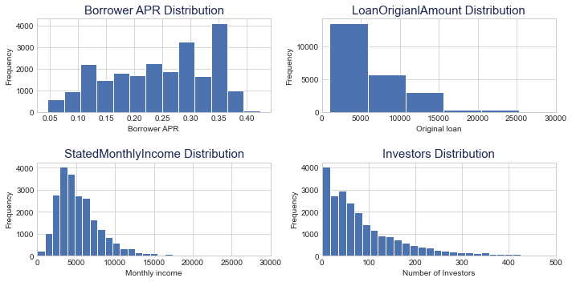

```python
fig = plt.figure(figsize=(10, 5))
plt.style.use('seaborn-whitegrid')

ax = plt.subplot(2, 2, 1)
df['BorrowerAPR'].hist(bins=13);
plt.xlabel('Borrower APR ')
plt.ylabel('Frequency')
title_obj = plt.title('Borrower APR Distribution', fontsize=15)
plt.setp(title_obj, color='#1D2951');

ax = plt.subplot(2, 2, 2)
df['LoanOriginalAmount'].hist(bins=7);
plt.xlim(0, 30000)
plt.xlabel('Original loan')
plt.ylabel('Frequency')
title_obj = plt.title('LoanOrigianlAmount Distribution', fontsize=15)
plt.setp(title_obj, color='#1D2951');


ax = plt.subplot(2, 2, 3)
df['StatedMonthlyIncome'].hist(bins=500);
plt.xlim(0, 30000)
plt.xlabel('Monthly income')
plt.ylabel('Frequency')
title_obj = plt.title('StatedMonthlyIncome Distribution', fontsize=15)
plt.setp(title_obj, color='#1D2951');

ax = plt.subplot(2, 2, 4)
df['Investors'].hist(bins=70);
plt.xlim(0, 500)
plt.xlabel('Number of Investors')
plt.ylabel('Frequency')
title_obj = plt.title('Investors Distribution', fontsize=15)
plt.setp(title_obj, color='#1D2951');
fig.tight_layout(h_pad=2)
```

LoanOriginalAmount, StatedMonthlyIncome and Investors distributions are highly right-skewed.

```python
# NO NEED FOR THIS BLOCK ANYMORE BUT I WILL LEAVE IT IN CASE
# THE FOLLOWING CODE PLOTS THE LOG-TRANSFORMATION OF THE RIGHT-SKEWED DATA SHOWN ABOVE AS A HISTOGRAM

# eps = np.nextafter(0, 1)

# fig = plt.figure(figsize=(15,5))

# ax = plt.subplot(1, 3, 1)
# bins = 10 ** np.arange(np.log10(df['LoanOriginalAmount'].min())-0.1, np.log10(df['LoanOriginalAmount'].max())+0.1, 0.15)
# ticks = [300, 1000, 3000, 10000, 30000]
# labels = ticks
# plt.hist(data=df, x='LoanOriginalAmount', bins=bins);
# plt.xscale('log')
# plt.xlabel('Original loan')
# plt.ylabel('Frequency')
# title_obj = plt.title('Modified LoanOrigianlAmount Distribution', fontsize=15)
# plt.setp(title_obj, color='#1D2951');
# # plt.xlim(1000, 50000)
# plt.xticks(ticks, labels)

# ax = plt.subplot(1, 3, 2)
# bins = 10 ** np.arange(np.log10(df['StatedMonthlyIncome'].min()+eps)-0.1, np.log10(df['StatedMonthlyIncome'].max())+0.1, 0.095)
# ticks = [300, 1000, 3000, 10000, 30000]
# labels = ticks
# plt.hist(data=df, x='StatedMonthlyIncome', bins=bins);
# plt.xlabel('Monthly income')
# plt.ylabel('Frequency')
# title_obj = plt.title('Modified StatedMonthlyIncome Distribution', fontsize=15)
# plt.setp(title_obj, color='#1D2951');
# plt.xscale('log')
# plt.xlim(500, 50000)
# plt.xticks(ticks, labels)

# ax = plt.subplot(1, 3, 3)
# bins = 10 ** np.arange(np.log10(df['Investors'].min()+eps)-0.1, np.log10(df['Investors'].max())+0.1, 0.185)
# ticks = [0.5, 10, 50, 100, 500, 1000]
# labels = ticks
# plt.hist(data=df, x='Investors', bins=bins);
# plt.xlabel('Investors')
# plt.ylabel('Frequency')
# title_obj = plt.title('Modified Investors Distribution', fontsize=15)
# plt.setp(title_obj, color='#1D2951');
# plt.xscale('log')
# plt.xlim(0, 500)
# plt.xticks(ticks, labels)

# fig.tight_layout(h_pad=2)
```

- **More detailed overview about the skewness of the numeric variables**

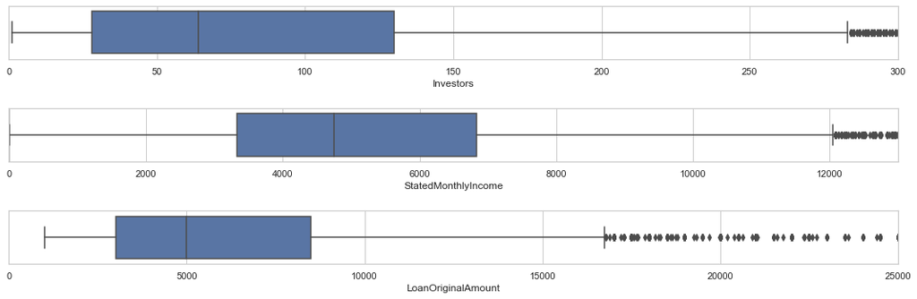

```python
fig = plt.figure(figsize=(15,5))
sns.set(font_scale=1)
sns.set_style('whitegrid')

ax = plt.subplot(3, 1, 1)
sns.boxplot(data=df, x ='Investors')
plt.xlim(0, 300)

ax = plt.subplot(3, 1, 2)
sns.boxplot(data=df, x ='StatedMonthlyIncome')
plt.xlim(-10, 13000)

ax = plt.subplot(3, 1, 3)
sns.boxplot(data=df, x ='LoanOriginalAmount')
plt.xlim(0, 25000)

fig.tight_layout(h_pad=2)
```

those variables have a lot of outliers (I cropped the plot to have an appropriate scale).  
I will leave these outliers as they are, cuz they will need more investigation, beyond the scope of this project, to choose a way to deal with them whether by modification or removing.

- **In the next part we will start seeing the correlations between variables whether they are categorical, boolean, or numeric**

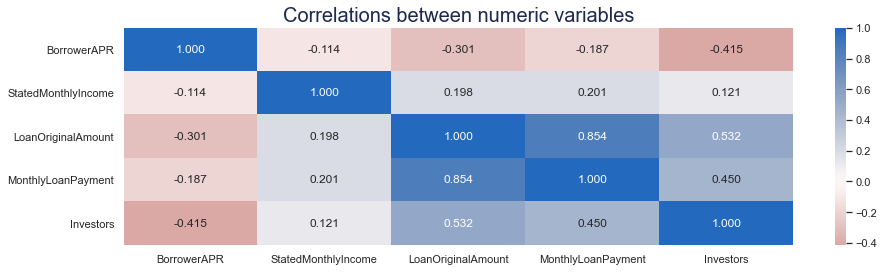

```python
# normally I would do this step after full cleaning data and removing outliers but whatever..
fig = plt.figure(figsize=(15, 4))
sns.heatmap(df[numeric_cols].corr(), annot = True, fmt = '.3f',
           cmap = 'vlag_r', center = 0)
# plt.show()
title_obj = plt.title('Correlations between numeric variables', fontsize=20)
plt.setp(title_obj, color='#1D2951');
```

from the correlation map above we can see that there is a negative correlation between Investors and BorrowerAPR  
and of course the monthy loan payment increases as the Original loan increases [Axioms] :D

Now we will see some relations associated with BorrowerAPR

```python
IncomeRange_classes = ['$1-24,999', '$25,000-49,999', '$50,000-74,999', '$75,000-99,999', '$100,000+']
IncomeClasses = pd.CategoricalDtype(ordered=True, categories=IncomeRange_classes)
df['IncomeRange'] = df['IncomeRange'].astype(IncomeClasses);
```

- **Effects of IncomeRange on BorrowerAPR**

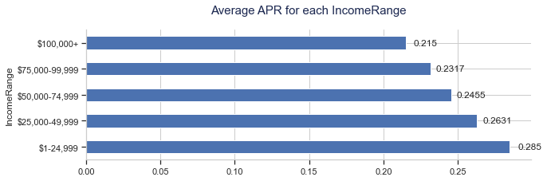

```python
income_apr = df.groupby('IncomeRange')['BorrowerAPR'].sum() / df.groupby('IncomeRange')['BorrowerAPR'].count()

fig = plt.figure(figsize=(10, 3))
ax = income_apr.plot(kind='barh')
decorate_barPlots(ax, title='Average APR for each IncomeRange', direction='h')
```

People with the lower incomeRange tend to have higher average APR, it is strange though.  
mabye due to their payment-delay?  
or maybe due to they have less investors?  
or mabye due to the fact that these people tend to NEED loans more than the other (e.g. for houses or Autos ..etc.).

We will see the relation between IncomeRange and the others to see why lower income range have higher APR.

- **Correlation between IncomeRange and Investors**

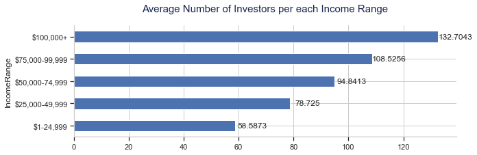

```python
income_apr = df.groupby('IncomeRange')['Investors'].sum() / df.groupby('IncomeRange')['Investors'].count()

fig = plt.figure(figsize=(10, 3))
ax = income_apr.plot(kind='barh')
decorate_barPlots(ax, title='Average Number of Investors per each Income Range', direction='h')
```

it seems like what we said above was true, people with lower income range tend to have fewer investors.

- **Correlation between Investors and ProsperRating**

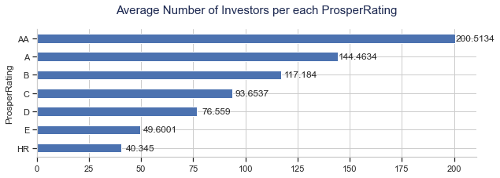

```python
income_apr = df.groupby('ProsperRating')['Investors'].sum() / df.groupby('ProsperRating')['Investors'].count()

fig = plt.figure(figsize=(10, 3))
ax = income_apr.sort_values().plot(kind='barh')
decorate_barPlots(ax, title='Average Number of Investors per each ProsperRating', direction='h')
```

Invistors increase is indication of a good ProsperRating.

- **Effects of ListingCategories on BorrowerAPR**

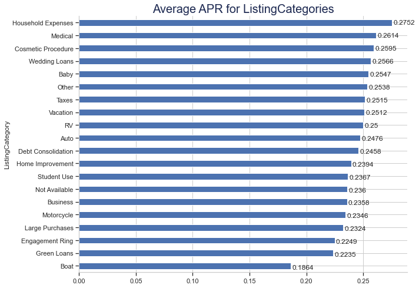

```python
Average_APR = df.groupby('ListingCategory')['BorrowerAPR'].sum()/ df.groupby('ListingCategory')['BorrowerAPR'].count()
ax = Average_APR.sort_values().plot(kind='barh', figsize=(10,8))

for p in ax.patches:
    ax.annotate(str(round(p.get_width(), 4)), ( p.get_width() * 1.005, p.get_y() * 1.005))

# Hide the right and top spines
ax.spines['right'].set_visible(False)
ax.spines['top'].set_visible(False)
# Only show ticks on the left and bottom spines
ax.yaxis.set_ticks_position('left')
ax.xaxis.set_ticks_position('bottom')

title_obj = plt.title('Average APR for ListingCategories', fontsize=20)
plt.setp(title_obj, color='#1D2951');
```

So, it seems that the HIGHEST APR tends to go for Household Expenses followed by Medical expenses.

- **Correlation between LoanOriginalAmount and BorrowerAPR**

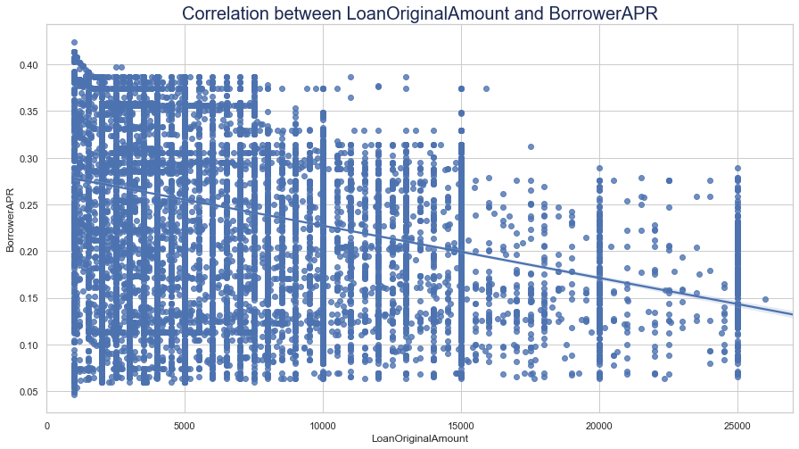

```python
plt.figure(figsize=(15,8))
sns.regplot(data=df, x="LoanOriginalAmount", y="BorrowerAPR")
plt.xlim(0, 27000)

title_obj = plt.title('Correlation between LoanOriginalAmount and BorrowerAPR', fontsize=20)
plt.setp(title_obj, color='#1D2951');
```

APR decreases as the LoanOriginalAmount increases. seems convincing.

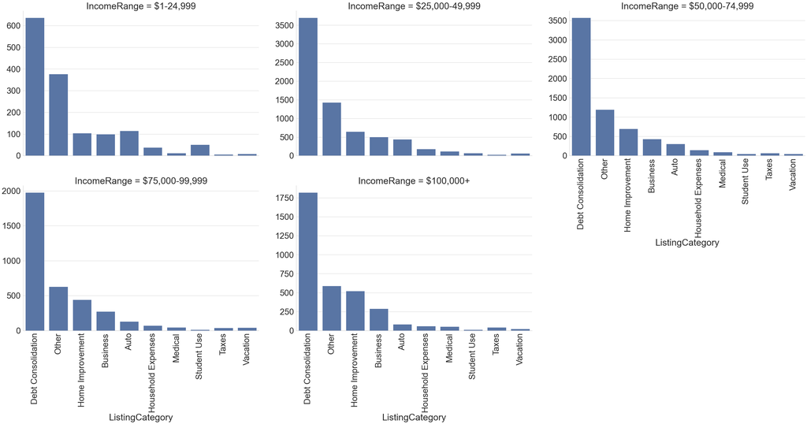

```python
sns.set(font_scale=3)
sns.set_style('whitegrid')
g = sns.FacetGrid(data = df, col = 'IncomeRange', col_wrap=3, sharey=False, height=10, aspect=1.5, margin_titles=True);
g.map(sns.countplot, 'ListingCategory', order=pd.value_counts(df['ListingCategory']).iloc[:10].index);
g.set_xticklabels(rotation=90);
```

```python
# convert columns to their right datatypes.
# df[datetype_cols] = df[datetype_cols].apply(pd.to_datetime)
# df[categorical_cols] = df[categorical_cols].apply(lambda x: x.astype('category'))
```

```python
# sns.set(font_scale=1)
# g = sns.FacetGrid(data = df, col = 'IsBorrowerHomeowner', col_wrap=2, sharey=False, height=5, aspect=1.1, margin_titles=True);
# g.map(sns.countplot, 'IncomeRange', order=df['IncomeRange'].unique().sort_values());
# g.set_xticklabels(rotation=90);
```

- **Effects of OwningHome, Employment, ProsperRating on LoanStatus**

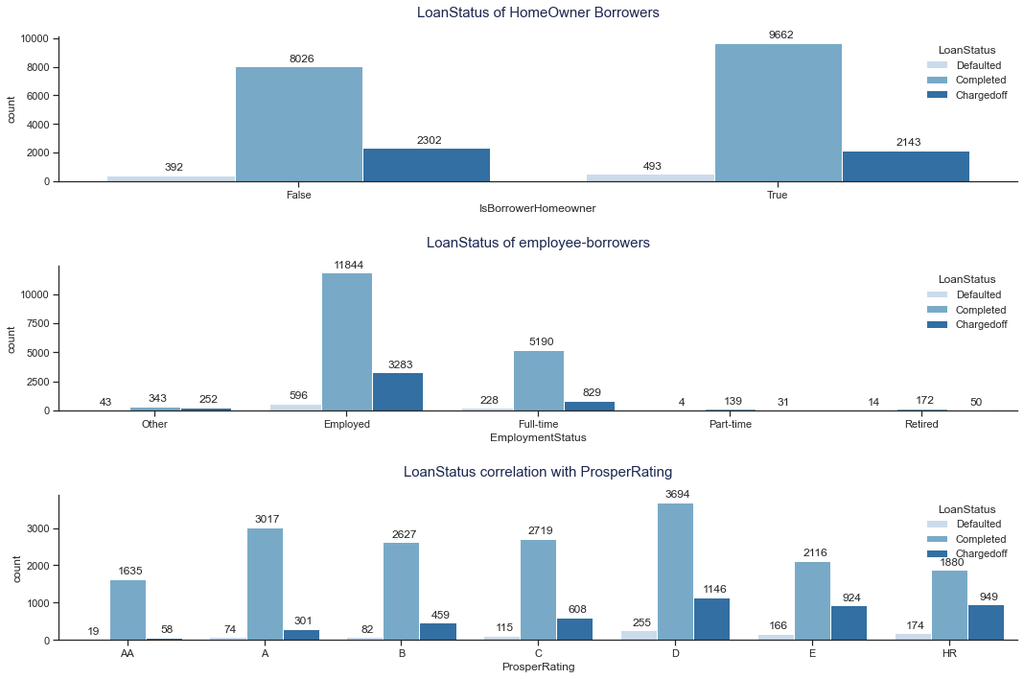

```python
fig = plt.figure(figsize=(15, 10))
sns.set(font_scale=1)
sns.set_style('white')

ax = plt.subplot(3, 1, 1)
ax = sns.countplot(data=df, x='IsBorrowerHomeowner', hue='LoanStatus', palette='Blues') # palette='crest'
decorate_barPlots(ax, title='LoanStatus of HomeOwner Borrowers', direction='v')

ax = plt.subplot(3, 1, 2)
ax = sns.countplot(data=df, x='EmploymentStatus', hue='LoanStatus', palette='Blues')
decorate_barPlots(ax, title='LoanStatus of employee-borrowers', direction='v')

ax = plt.subplot(3, 1, 3)
ax = sns.countplot(data=df, x='ProsperRating', hue='LoanStatus', palette='Blues')
decorate_barPlots(ax, title='LoanStatus correlation with ProsperRating', direction='v')

fig.tight_layout(h_pad=2)
```

Borrowers with their own houses tend to complete the loan more than the others.  
Number of Chargedoff borrowers tend to follow the ProsperRating scale, as risk increases charing increases which is pretty obvious :D

I don't know what 'Employed' mean here as both 'full-time' and 'part-time' are subsets of 'Employed' Category right?  
It seems that it includes more than full-time, part-time, and others combined. (I won't add it in the analysis results)

- **Correlation between IncomeRange and OwningHome**

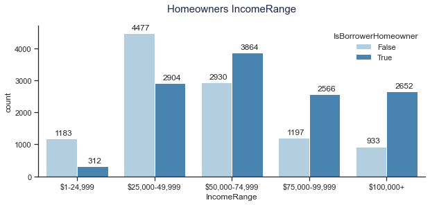

```python
plt.figure(figsize=(10,4))
sns.set(font_scale=1)
sns.set_style('white')
ax = sns.countplot(data=df, x='IncomeRange', hue='IsBorrowerHomeowner', palette='Blues')
decorate_barPlots(ax, title='Homeowners IncomeRange', direction='v')
```

Ratio between people with higher IncomeRange who own houses to who don't is higher than the people with lower IncomeRange and therefore this category have higher creditability for completing the loan which confirms the previous results.

- **Correlation between MonthlyIncome, ProsperRating and LoanStatus**

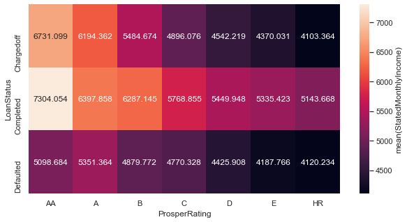

```python
plt.figure(figsize=(10,5))
avgs = df.groupby(['LoanStatus', 'ProsperRating']).mean()['StatedMonthlyIncome']
avgs = avgs.reset_index(name = 'StatedMonthlyIncome_AVG');
avgs = avgs.pivot(index = 'LoanStatus', columns = 'ProsperRating', values = 'StatedMonthlyIncome_AVG');
sns.heatmap(avgs, annot = True, fmt = '.3f', cbar_kws = {'label' : 'mean(StatedMonthlyIncome)'});
```

This summarize the correlations between monthlyIncome, ProsperRating, and LoanStatus  
As MonthlyIncome increases, the borrower gain a good prosperrating and eventually he completes the loan.

- **Correlation between MonthlyLoanPayment, ProsperRating and LoanStatus**

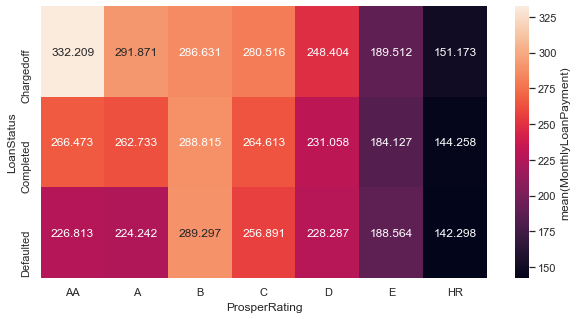

```python
plt.figure(figsize=(10,5))
avgs = df.groupby(['LoanStatus', 'ProsperRating']).mean()['MonthlyLoanPayment']
avgs = avgs.reset_index(name = 'MonthlyLoanPayment_AVG');
avgs = avgs.pivot(index = 'LoanStatus', columns = 'ProsperRating', values = 'MonthlyLoanPayment_AVG');
sns.heatmap(avgs, annot = True, fmt = '.3f', cbar_kws = {'label' : 'mean(MonthlyLoanPayment)'});
```

We got an interesting results here, indicating that if the monthly loan payment increased over a certain point, EVEN IF the borrower is considered in a AA-ProsperRating-category, debt is unlikely to be collected.

```python
# sns.set(font_scale=2, style='white')
# g = sns.FacetGrid(data = df, hue = 'LoanStatus', palette = 'colorblind', height=7, aspect=3)
# g.map(plt.scatter, 'StatedMonthlyIncome', 'MonthlyLoanPayment', linewidth=0.5, alpha=0.6)
# g.map(sns.regplot, "StatedMonthlyIncome", "MonthlyLoanPayment", ci=None, robust=1)

# g.add_legend()
# plt.xlim(0, 40000)
# plt.ylim(0, 1000);
```

**Conclusions**